# AJB2021_FVT_CEPF_Analysis

Robert L. Baker

12/23/2020

Abstract

This document includes an example dataset, code for fitting a logistic growth curve to FVT, generating plots, and then analyzing the data using a parameters as data approach.

## Data Background and Explanation

These data were generated at the CEPF at Purdue University in 2020 as part of a larger experiment. Here we analyze a subset of the data from two genotypes of *Brassica rapa* (L58 & R500) in a single control treatment and the single response variable “TopPlantSurface”. Plants were grown in a consistent, growth chamber environment and watering was automated. Each weekday, plants exited the growth chamber on an automated conveyor belt and passed through an array of phenotyping equipment. Data analyzed here are from a camera aimed directly down at the center of each pot. TopPlantSurface is generated from RGB image data and is extracted from the image using custom software specific to the CEPF (but remarkably reminiscent of openCV or PlantCV). TopPlantSurface consists of all the pixels identified as “Plant” from this overhead view and is a likely proxy for plant growth, photosynthetic area, biomass, etc. Also note that these are not raw data; obviously erroneous data points have been dropped. For instance, on one day the watering regime was off and the plants wilted, leading to abnormally small values for “TopPlantSurface”. One replicate appeared to be mislabeled and was also dropped from the analysis outlined below.

#### Prep for analysis:

```r
rm(list=ls()) #remove all objects from the R environment
gc() #can help return memory to R after large objects have been called.

#load necessary packages
library(plyr)
library(lubridate)
library(car)
library(tidyverse)

#load the data (from Sumplemtental Information S1 of this publication)
dat<-read.csv(file="CEPF_TopSurface2020.csv")
```

#### Convert data collection date from mm/dd/yy to “days from planting”.

Unfortunately we don’t have germination date, which would be better than planting date. Luckily for these genotypes there is typically very little difference in days to germination.

```r
#take a look at the data
head(dat)
```

```
##   PlantID Genotype Replicate ExperimentID PlantDate DataDate TopPlantSurface
## 1  200240      L58         1           12    2/4/20  2/13/20               0
## 2  200240      L58         1           12    2/4/20  2/21/20            2767
## 3  200240      L58         1           12    2/4/20  2/24/20            7709
## 4  200240      L58         1           12    2/4/20  2/26/20           14248
## 5  200240      L58         1           12    2/4/20  2/28/20           24743
## 6  200240      L58         1           12    2/4/20   3/2/20           43542
```

```r
#convert date formats from mm/dd/yy to Julian days:
dat$PlantDate<-as.Date(dat$PlantDate, format="%m/%d/%Y")
dat$PlantDate<-format(dat$PlantDate, "%j")
dat$PlantDate<-as.numeric(dat$PlantDate)

dat$DataDate<-as.Date(dat$DataDate, format="%m/%d/%Y")
dat$DataDate<-format(dat$DataDate, "%j")
dat$DataDate<-as.numeric(dat$DataDate)

#generate a new column, "DataDate", which is the time between planting and the observation, in days
dat$DataDate<-dat$DataDate-dat$PlantDate

#take a look at the data again:
head(dat)
```

```
##   PlantID Genotype Replicate ExperimentID PlantDate DataDate TopPlantSurface
## 1  200240      L58         1           12        35        9               0
## 2  200240      L58         1           12        35       17            2767
## 3  200240      L58         1           12        35       20            7709
## 4  200240      L58         1           12        35       22           14248
## 5  200240      L58         1           12        35       24           24743
## 6  200240      L58         1           12        35       27           43542
```

#### Visual data inspection:

```r
#dat$DataDate<-as.factor(dat$DataDate) #convert to factor

#get max and min values to set y-axis limits on plots:
min(dat$TopPlantSurface, na.rm=TRUE) #minimum value
```

```
## [1] 0
```

```r
max(dat$TopPlantSurface, na.rm=TRUE) #maximum value
```

```
## [1] 96566
```

```r
dat_split<-split(dat, dat$PlantID) #split the dataframe into multiple dataframes, one for each individual plant (PlantID) and place all of these dataframes in a list of dataframes.

j<-unique(dat$PlantID) #j is a list of all the individual plant IDs
length(j) # the number of plants in the analysis
```

```
## [1] 7
```

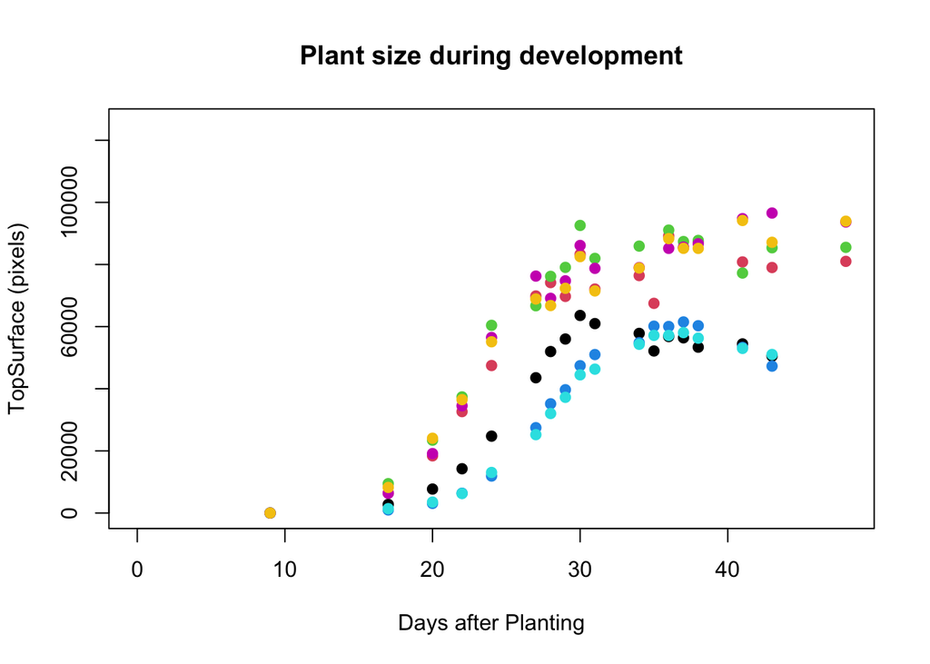

```r
plot(NULL, xlim=c(0,48), ylim=c(0,125089), ylab="TopSurface (pixels)", xlab="Days after Planting", main="Plant size during development") #set up an empty plot

#generate a plot where each color is a different plant for data inspection purposes:
for(i in 1:length(j)){
    yvalues<-dat_split[[i]][7]
    y2values<-yvalues$TopPlantSurface
    xvalues<-dat_split[[i]][6]
    x2values<-xvalues$DataDate
    main<-dat_split[[i]][1]
    geno<-dat_split[[i]][2]

    points(x2values,y2values, pch=19, col=i)
}
```

#### Fit a logistic growth curve to a single plant

Once you are satisfied that your data can be fit with a specific function, in this case a logistic growth curve, you can fit the curve to the data. First, test this out the curve fitting procedure with an individual plant:

```r
#Grab just one plant:
tester<-dat_split[[2]]
head(tester)
```

```
##    PlantID Genotype Replicate ExperimentID PlantDate DataDate TopPlantSurface
## 18  200241     R500         3           12        35        9               0
## 19  200241     R500         3           12        35       17            6405
## 20  200241     R500         3           12        35       20           18404
## 21  200241     R500         3           12        35       22           32637
## 22  200241     R500         3           12        35       24           47475
## 23  200241     R500         3           12        35       27           69865
```

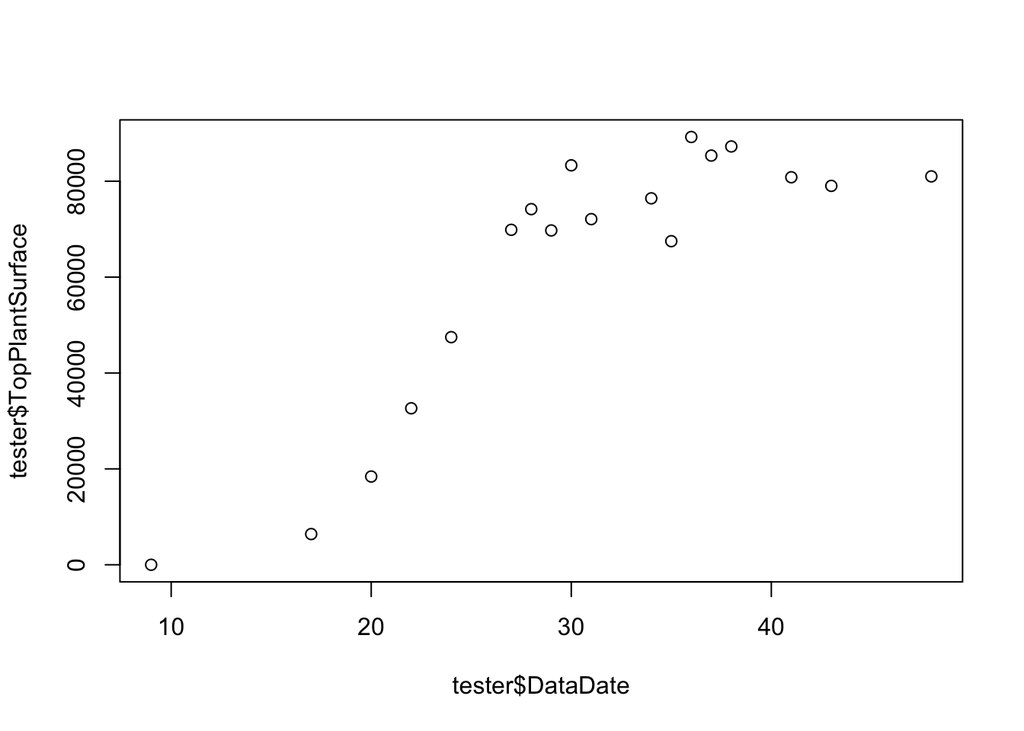

```r
#plot it just to make sure:
plot(tester$DataDate, tester$TopPlantSurface)
```

```r
#fit a self-starting logistic growth model using non-linear regression.
plant.ss<-nls(TopPlantSurface ~ SSlogis(DataDate, phi1, phi2, phi3), data=tester)
#phi1: upper asymptote
#phi2: value of x where y=0.5*phi1 (inflection point)
#phi3: rate parameter

#model summary:
summary(plant.ss)
```

```
##
## Formula: TopPlantSurface ~ SSlogis(DataDate, phi1, phi2, phi3)
##
## Parameters:
##       Estimate Std. Error t value Pr(>|t|)
## phi1 8.105e+04  1.926e+03  42.085  < 2e-16 ***
## phi2 2.300e+01  4.180e-01  55.019  < 2e-16 ***
## phi3 2.452e+00  3.673e-01   6.675 7.41e-06 ***
## ---
## Signif. codes:  0 '***' 0.001 '**' 0.01 '*' 0.05 '.' 0.1 ' ' 1
##
## Residual standard error: 5394 on 15 degrees of freedom
##
## Number of iterations to convergence: 1
## Achieved convergence tolerance: 1.266e-06
##   (1 observation deleted due to missingness)
```

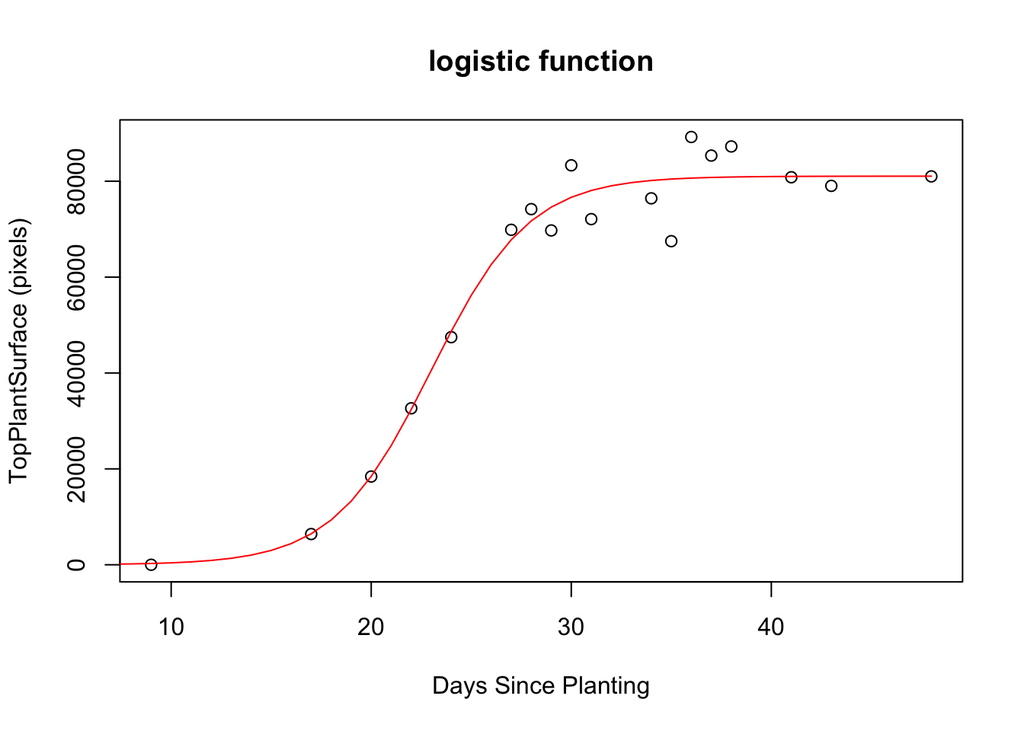

```
##            Logistic Curve
## Asymptoe     81054.223683
## Inflection      22.998709
## rate             2.451819
```

```r
#write a function to do the logistic growth curve model fits:
log.fit<-function(TopPlantSurface, DataDate, tester){

y<-tester[,"TopPlantSurface"]
x<-tester[,"DataDate"]

log.ss<-nls(y~SSlogis(x, phi1, ph2, phi3))

A<-summary(log.ss)$coef[1] #phi1: upper asymptote
I<-summary(log.ss)$coef[2] #phi2: value of x where y=0.5*phi1 (inflection point)
r<-summary(log.ss)$coef[3] #phi3: rate parameter

plot(y~x, main="logistic function", xlab="Days Since Planting", ylab="TopPlantSurface (pixels)")
lines(0:max(x), predict(log.ss, data.frame(x=0:max(x))), col="red")

out<-data.frame(cbind(c(Asymptoe=A, Inflection=I, rate=r)))
names(out)[1]<-"Logistic Curve"

return(out)
}

log.fit(TopPlantsurface, DataDate, tester)
```

#### Calculate and plot logistic growth curves for all individual plants

Also, extract parameters describing the logistic growth curve for each plant

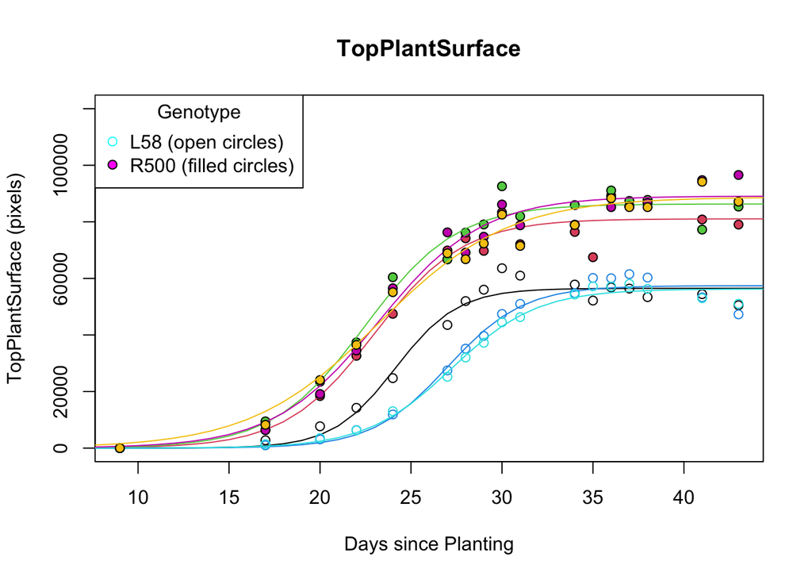

```r
#Set up some empty lists
ID<-NULL
Geno<-NULL
Max<-NULL
Infl<-NULL
Growth<-NULL

#Set up a plot
    plot(1, type="n", xlim=c(9,43), ylim=c(0,120000), main="TopPlantSurface", ylab="TopPlantSurface (pixels)", xlab="Days since Planting")
    legend(x="topleft", title="Genotype", legend=c("L58 (open circles)", "R500 (filled circles)"),
       pch=21, col=c("cyan", "black"), pt.bg=c("white", "magenta"))

    for(i in 1:length(j)){
        tester<-dat_split[[i]]
        y<-tester[,"TopPlantSurface"]
        x<-tester[,"DataDate"]

    #fit logistic growth curves to each L58 plant, individually:
    if(tester[2,2]=="L58"){
        log.ss<-nls(y~SSlogis(x, phi1, phi2, phi3))

        #extract parameters & confidence intervals
        max<-Confint(log.ss)[[1]]
        infl<-Confint(log.ss)[[2]]
        growth<-Confint(log.ss)[[3]]

        #plot L58 genotypes (open circles):
        points(y~x, pch=21, col=i)
        lines(0:45, predict(log.ss, data.frame(x=0:45)), col=i)
        }

    #fit logistic growth curves to each R500 plant, individually:
    if(tester[2,2]=="R500"){
        log.ss<-nls(y~SSlogis(x, phi1, ph2, ph3))

        max<-Confint(log.ss)[[1]]
        infl<-Confint(log.ss)[[2]]
        growth<-Confint(log.ss)[[3]]

        #plot R500 genotypes (closed circles):
        points(y~x, pch=21, col="black", bg=i)
        lines(0:45, predict(log.ss, data.frame(x=0:45)), col=i)
        }

        geno<-tester$Genotype[1]
        ID<-c(ID,tester[1,1])
        Geno<-c(Geno,geno)
        Max<-c(Max,max)
        Infl<-c(Infl, infl)
        Growth<-c(Growth, growth)
}
```

#### Satisfied with the fits, time to work with downstream analyses:

Using a “parameters as data” approach.

```r
#dataframe of extracted logistic growth parameters

out<-data.frame(cbind(ID, Geno, Max, Infl, Growth))
out$Geno<-as.factor(out$Geno)

#Basic linear models for each parameter:
Maxmod<-lm(Max~Geno, data=out)
summary(Maxmod)
```

```
##
## Call:
## lm(formula = Max ~ Geno, data = out)
##
## Residuals:
##        1        2        3        4        5        6        7
##  -232.94 -5247.16    15.14   695.56  -462.62  2795.48  2436.54
##
## Coefficients:
##             Estimate Std. Error t value Pr(>|t|)
## (Intercept)    56718       1674   33.88 4.21e-07 ***
## GenoR500       29584       2215   13.36 4.20e-05 ***
## ---
## Signif. codes:  0 '***' 0.001 '**' 0.01 '*' 0.05 '.' 0.1 ' ' 1
##
## Residual standard error: 2900 on 5 degrees of freedom
## Multiple R-squared:  0.9727, Adjusted R-squared:  0.9673
## F-statistic: 178.5 on 1 and 5 DF,  p-value: 4.205e-05
```

```r
Inflmod<-lm(Infl~Geno, data=out)
summary(Inflmod)
```

```
##
## Call:
## lm(formula = Infl ~ Geno, data = out)
##
## Residuals:
##        1        2        3        4        5        6        7
## -1.98662  0.01876 -0.50855  0.88574  1.10087  0.21353  0.27626
##
## Coefficients:
##             Estimate Std. Error t value Pr(>|t|)
## (Intercept)  26.1234     0.6493   40.23 1.79e-07 ***
## GenoR500     -3.1435     0.8590   -3.66   0.0146 *
## ---
## Signif. codes:  0 '***' 0.001 '**' 0.01 '*' 0.05 '.' 0.1 ' ' 1
##
## Residual standard error: 1.125 on 5 degrees of freedom
## Multiple R-squared:  0.7282, Adjusted R-squared:  0.6738
## F-statistic: 13.39 on 1 and 5 DF,  p-value: 0.0146
```

```r
Growthmod<-lm(Growth~Geno, data=out)
summary(Growthmod)
```

```
##
## Call:
## lm(formula = Growth ~ Geno, data = out)
##
## Residuals:
##        1        2        3        4        5        6        7
## -0.32844 -0.39388 -0.31739  0.03279  0.29565  0.01449  0.69679
##
## Coefficients:
##             Estimate Std. Error t value Pr(>|t|)
## (Intercept)   2.0451     0.2501   8.178 0.000444 ***
## GenoR500      0.8007     0.3308   2.420 0.060092 .
## ---
## Signif. codes:  0 '***' 0.001 '**' 0.01 '*' 0.05 '.' 0.1 ' ' 1
##
## Residual standard error: 0.4331 on 5 degrees of freedom
## Multiple R-squared:  0.5395, Adjusted R-squared:  0.4474
## F-statistic: 5.858 on 1 and 5 DF,  p-value: 0.06009
```

#### Documentation and citations:

```
##
##   R Core Team (2020). R: A language and environment for statistical
##   computing. R Foundation for Statistical Computing, Vienna, Austria.
##   URL https://www.R-project.org/.
```

```
## [1] "R-4.0.2_2020-06-22"
```

```
##
##
##   Garrett Grolemund, Hadley Wickham (2011). Dates and Times Made Easy
##   with lubridate. Journal of Statistical Software, 40(3), 1-25. URL
##   http://www.jstatsoft.org/v40/i03/.
```

```
##
##
##   John Fox and Sanford Weisberg (2019). An {R} Companion to Applied
##   Regression, Third Edition. Thousand Oaks CA: Sage. URL:
##   https://socialsciences.mcmaster.ca/jfox/Books/Companion/
```

```
##
##
##   Hadley Wickham (2011). The Split-Apply-Combine Strategy for Data
##   Analysis. Journal of Statistical Software, 40(1), 1-29. URL
##   http://www.jstatsoft.org/v40/i01/.
```

```
##
##   Wickham et al., (2019). Welcome to the tidyverse. Journal of Open
##   Source Software, 4(43), 1686, https://doi.org/10.21105/joss.01686
```